# S6_informe

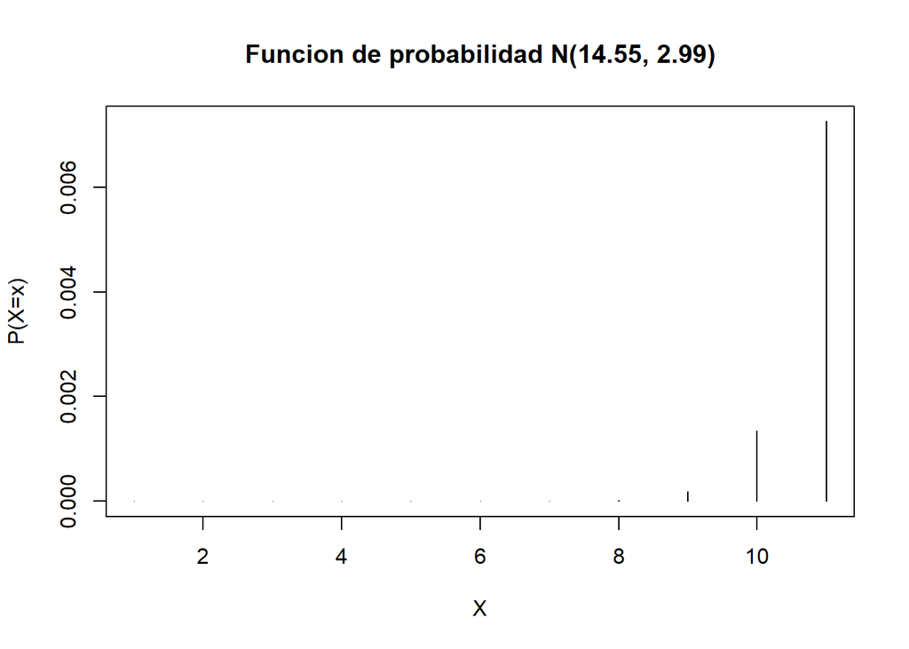

```r
plot(dnorm(0:10,mu,sigma),type = "h",xlab="X",ylab="P(X=x)",main="Funcion de probabilidad N(14.55, 2.99)")
```

```r
#Hallar la probabilidad de que un alumno tengas más de 15 puntos de promedio
N2<-pnorm(15,mu,sigma,lower.tail = FALSE)
N2
```

```
## [1] 0.3973873
```

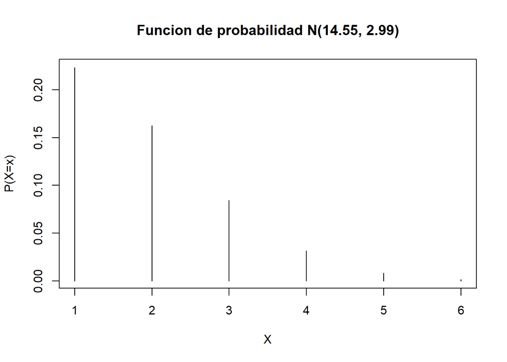

```r
plot(dnorm(15:20,mu,sigma),type = "h",xlab="X",ylab="P(X=x)",main="Funcion de probabilidad N(14.55, 2.99)")
```

```r
#Hallar la probabilidad de que tenga nota entre 12 y 18 puntos de promedio
N3<-pnorm(18,mu,sigma)-pnorm(12,mu,sigma)
N3
```

```
## [1] 0.9066936
```

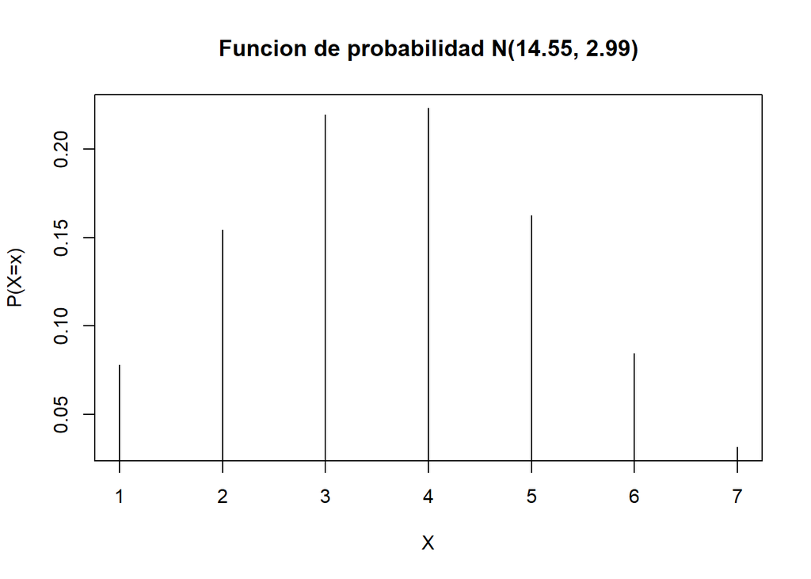

```r
plot(dnorm(12:18,mu,sigma),type = "h",xlab="X",ylab="P(X=x)",main="Funcion de probabilidad N(14.55, 2.99)")
```

# Bibliografia

[*Rodríguez Rodríguez, Daniel, & Guzmán Rosquete, Remedios. (2019). Rendimiento académico y factores sociofamiliares de riesgo. Variables personales que moderan su influencia. Perfiles educativos, 41(164), 118-134. https://doi.org/10.22201/iisue.24486167e.2019.164.58925*](https://www.scielo.org.mx/scielo.php?script=sci_arttext&pid=S0185-26982019000200118)

[*Martínez Chairez, G. I., Torres Díaz, M. J., & Ríos Cepeda, V. L. (2020). El contexto familiar y su vinculación con el rendimiento académico. IE Revista De Investigación Educativa De La REDIECH, 11, e657. https://doi.org/10.33010/ie_rie_rediech.v11i0.657*](https://www.redalyc.org/journal/5216/521662150008/html/)

[*Reyes-González, Nicolás, Meneses-Báez, Alba L., & Díaz-Mujica, Alejandro. (2022). Planificación y gestión del tiempo académico de estudiantes universitarios. Formación universitaria, 15(1), 57-72. https://dx.doi.org/10.4067/S0718-50062022000100057*](https://www.scielo.cl/scielo.php?script=sci_arttext&pid=S0718-50062022000100057&lang=es)